# Canopy Reference Document

Anwesha Guha

3/25/2022

The chunk above is called the YAML. It contains basic information about the document.

## File Setup

Next, you need to set up libraries you need for your analysis. Insert a new code chunk by using the green +c button on the top right. Import the four libraries below. We can add more if we want later, but these should be enough for initial analysis and data cleaning.

```r
library(here)
library(rio)
library(tidyverse)
library(janitor)
```

## Data Cleaning

Next, you need to import data into R. I am using the data from the old canopy Github for this. The Github is linked [here](https://github.com/project-evident/canopy/tree/master/data).

```r
tags <- read.csv("https://raw.githubusercontent.com/project-evident/canopy/master/data/Canopy%20Tags%20Public%20Access.csv")
```

Next, we want to make sure the variable names are clean and consistent. This code makes the variable names lowercase and words separated by underscores.

```r
tags <- tags %>%
  clean_names()
```

## Data Analysis

Now, time for the analysis! This section will be very basic, since much of the exploration will vary person to person.

Given this data, we could try to see general approaches vs. specific practices.

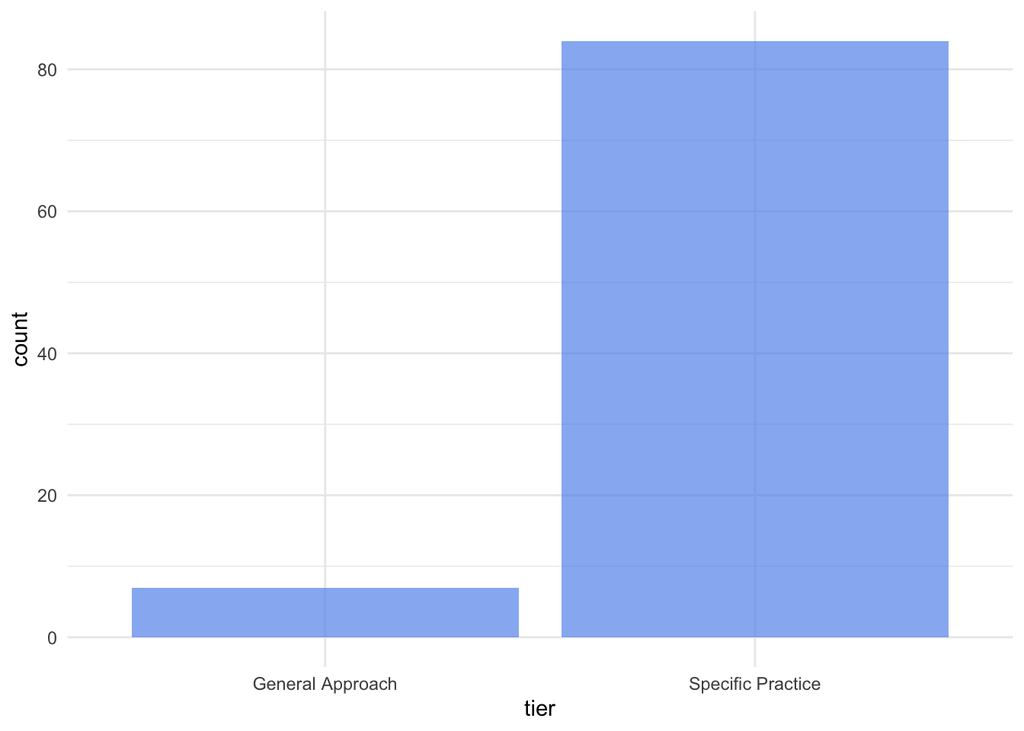

```r
general_specific_plot <- tags %>%
  ggplot(aes(tier)) +
  geom_bar(fill = "cornflowerblue", alpha = .7) +
  theme_minimal()

general_specific_plot
```

Finally, once you make sure everything is running, you can knit the file, which converts your work to an HTML document.